# Data visualization with seaborn - part I

```python
import warnings
warnings.filterwarnings('ignore')

import pandas as pd
import matplotlib.pyplot as plt
import seaborn as sns
%matplotlib inline
```

```python
plt.rcParams['figure.figsize']=6,6
```

```python
penguins = sns.load_dataset('penguins')
```

```python
penguins
```

|  | species | island | bill_length_mm | bill_depth_mm | flipper_length_mm | body_mass_g | sex |
| --- | --- | --- | --- | --- | --- | --- | --- |
| 0 | Adelie | Torgersen | 39.1 | 18.7 | 181.0 | 3750.0 | Male |
| 1 | Adelie | Torgersen | 39.5 | 17.4 | 186.0 | 3800.0 | Female |
| 2 | Adelie | Torgersen | 40.3 | 18.0 | 195.0 | 3250.0 | Female |
| 3 | Adelie | Torgersen | NaN | NaN | NaN | NaN | NaN |
| 4 | Adelie | Torgersen | 36.7 | 19.3 | 193.0 | 3450.0 | Female |
| ... | ... | ... | ... | ... | ... | ... | ... |
| 339 | Gentoo | Biscoe | NaN | NaN | NaN | NaN | NaN |
| 340 | Gentoo | Biscoe | 46.8 | 14.3 | 215.0 | 4850.0 | Female |
| 341 | Gentoo | Biscoe | 50.4 | 15.7 | 222.0 | 5750.0 | Male |
| 342 | Gentoo | Biscoe | 45.2 | 14.8 | 212.0 | 5200.0 | Female |
| 343 | Gentoo | Biscoe | 49.9 | 16.1 | 213.0 | 5400.0 | Male |

344 rows × 7 columns

```python
penguins.info()
```

```
<class 'pandas.core.frame.DataFrame'>
RangeIndex: 344 entries, 0 to 343
Data columns (total 7 columns):
 #   Column             Non-Null Count  Dtype
---  ------             --------------  -----
 0   species            344 non-null    object
 1   island             344 non-null    object
 2   bill_length_mm     342 non-null    float64
 3   bill_depth_mm      342 non-null    float64
 4   flipper_length_mm  342 non-null    float64
 5   body_mass_g        342 non-null    float64
 6   sex                333 non-null    object
dtypes: float64(4), object(3)
memory usage: 18.9+ KB
```

```python
penguins.describe()
```

|  | bill_length_mm | bill_depth_mm | flipper_length_mm | body_mass_g |
| --- | --- | --- | --- | --- |
| count | 342.000000 | 342.000000 | 342.000000 | 342.000000 |
| mean | 43.921930 | 17.151170 | 200.915205 | 4201.754386 |
| std | 5.459584 | 1.974793 | 14.061714 | 801.954536 |
| min | 32.100000 | 13.100000 | 172.000000 | 2700.000000 |
| 25% | 39.225000 | 15.600000 | 190.000000 | 3550.000000 |
| 50% | 44.450000 | 17.300000 | 197.000000 | 4050.000000 |
| 75% | 48.500000 | 18.700000 | 213.000000 | 4750.000000 |
| max | 59.600000 | 21.500000 | 231.000000 | 6300.000000 |

```python
penguins.dropna(inplace=True)
```

## Simple distribution plots

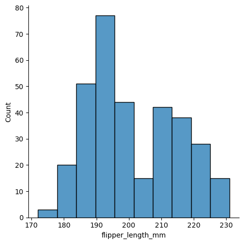

```python
sns.displot(penguins["flipper_length_mm"])
```

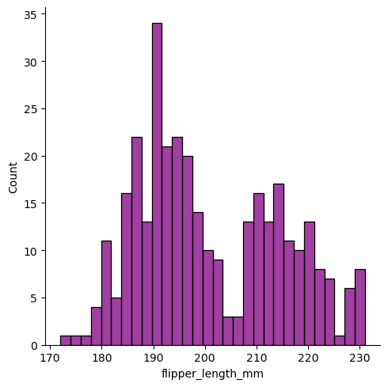

```python
sns.displot(penguins["flipper_length_mm"],color='purple',bins=30)
```

[figure not shown]

```python
sns.displot()
```

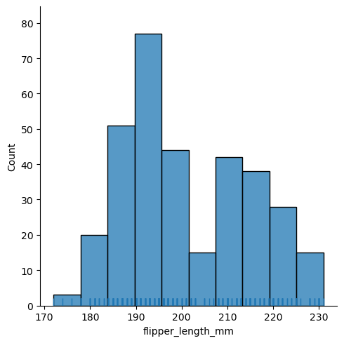

```python
sns.displot(penguins["flipper_length_mm"],kind="hist", rug=True)
```

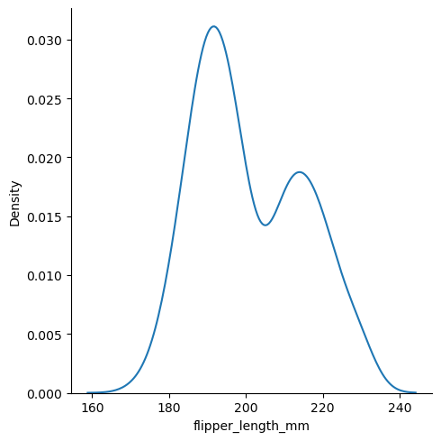

```python
sns.displot(penguins["flipper_length_mm"],kind="kde")
```

## Scatter plots

Provide insights regarding the relationships amongst two variables

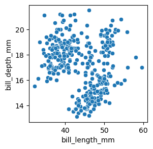

```python
sns.scatterplot(x='bill_length_mm', y='bill_depth_mm', data=penguins)
```

We can easily change the size using the `s` argument

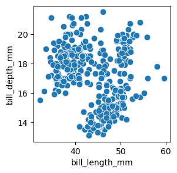

```python
sns.scatterplot(x='bill_length_mm', y='bill_depth_mm',s=60, data=penguins)
```

Using color we can gain insights about a third variable

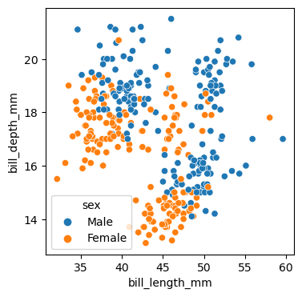

```python
sns.scatterplot(x='bill_length_mm', y='bill_depth_mm', hue='sex', data=penguins)
```

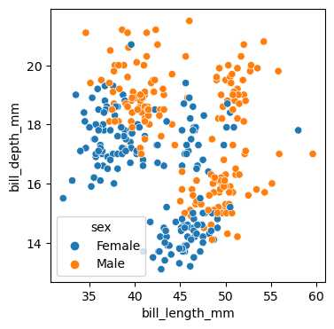

```python
sns.scatterplot(x='bill_length_mm', y='bill_depth_mm', hue='sex',
                hue_order=['Female','Male'], data=penguins)
```

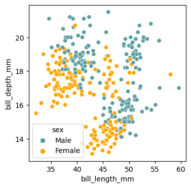

```python
hue_colors = {'Female': 'orange', 'Male':'cadetblue'}
sns.scatterplot(x='bill_length_mm', y='bill_depth_mm', hue='sex',
                palette=hue_colors, data=penguins)
```

We can use different symbol for each category

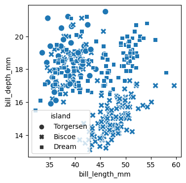

```python
sns.scatterplot(x='bill_length_mm', y='bill_depth_mm',
                style='island',s=80, data=penguins)
```

In the previous the variable we used for `hue` was categorical. Let's see what happens if we include a continous variable

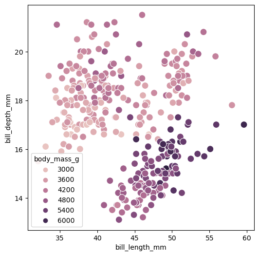

```python
sns.scatterplot(x='bill_length_mm', y='bill_depth_mm',
                hue='body_mass_g', s=100, data=penguins)
```

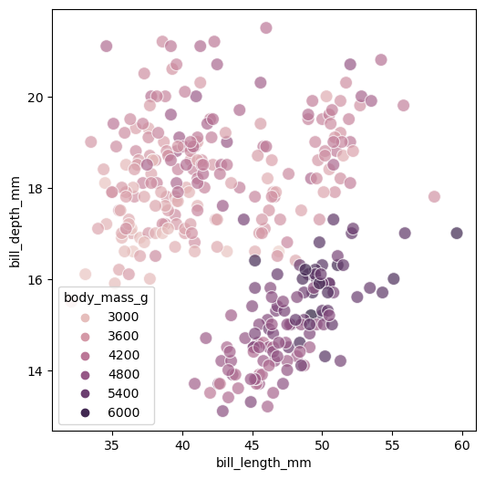

```python
sns.scatterplot(x='bill_length_mm', y='bill_depth_mm',
                hue='body_mass_g',s=100, alpha=0.7, data=penguins)
```

## A different type of visualization of two variables

```python
sns.jointplot?
```

[output not shown]

[output cut: 40 more lines]

[output not shown]

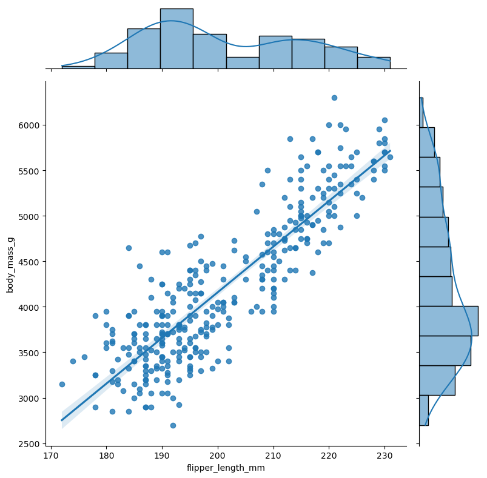

```python
sns.jointplot(
    data=penguins,
    x='flipper_length_mm',
    y='body_mass_g',
    height=8,
    kind='reg')
```

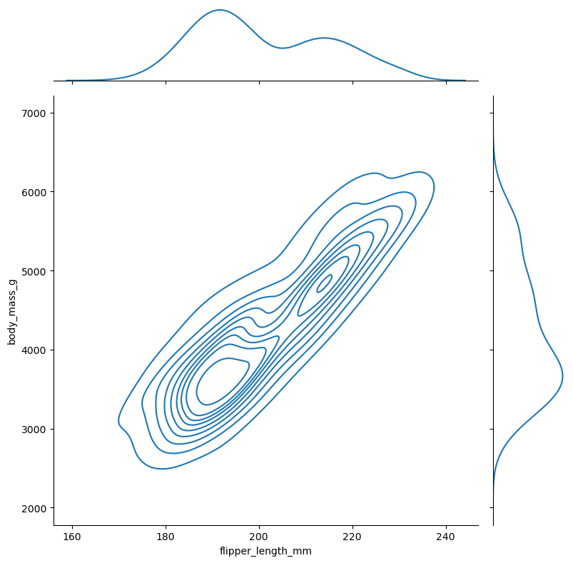

```python
sns.jointplot(
    data=penguins,
    x='flipper_length_mm',
    y='body_mass_g',
    height=8,
    kind='kde',
    cbar=False)
```

## Count plots

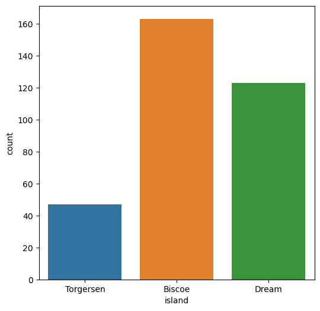

```python
sns.countplot(x='island', data=penguins)
```

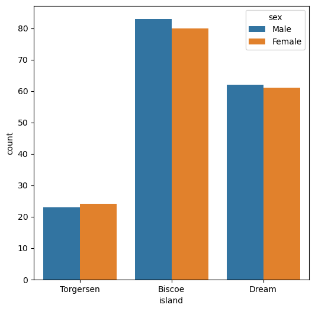

```python
sns.countplot(x='island', hue='sex', data=penguins)
```

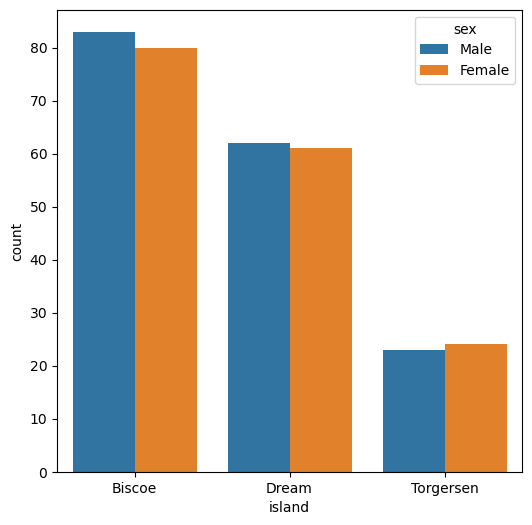

```python
sns.countplot(x='island', hue='sex',order=['Biscoe', 'Dream', 'Torgersen'], data=penguins)
```

## Easy creation of multiple graphs

Below we see two flexible approaches for easy creation of multiple graphs named `relplot` and `catplot` that can be used instead of `scatterplot` and `countplot` respectively

### `relplot`

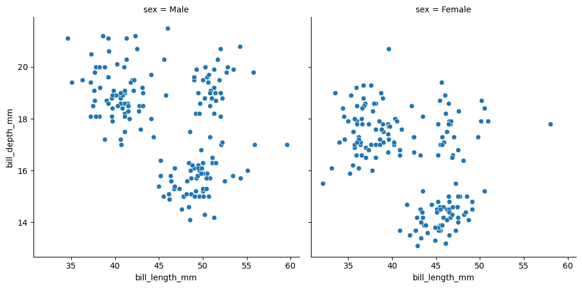

```python
sns.relplot(x='bill_length_mm', y='bill_depth_mm',
            col='sex', data=penguins, kind='scatter')
```

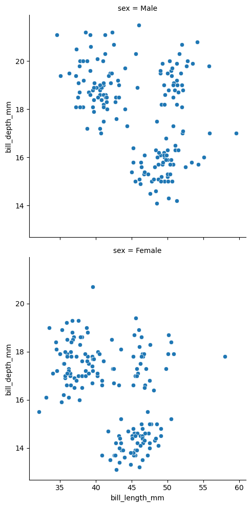

```python
sns.relplot(x='bill_length_mm', y='bill_depth_mm',
            row='sex', kind='scatter', data=penguins)
```

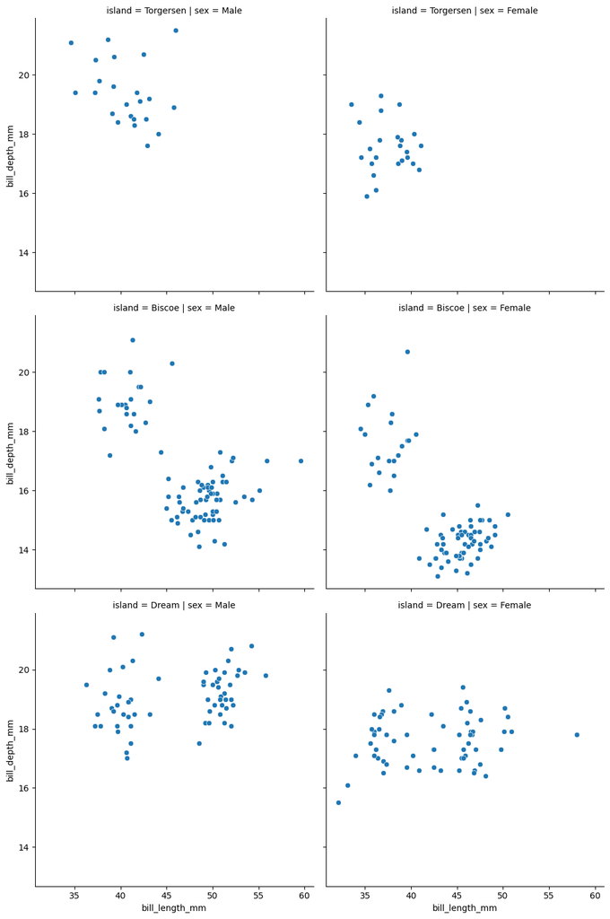

```python
sns.relplot(x='bill_length_mm', y='bill_depth_mm',
            row='island',col='sex',kind='scatter', data=penguins)
```

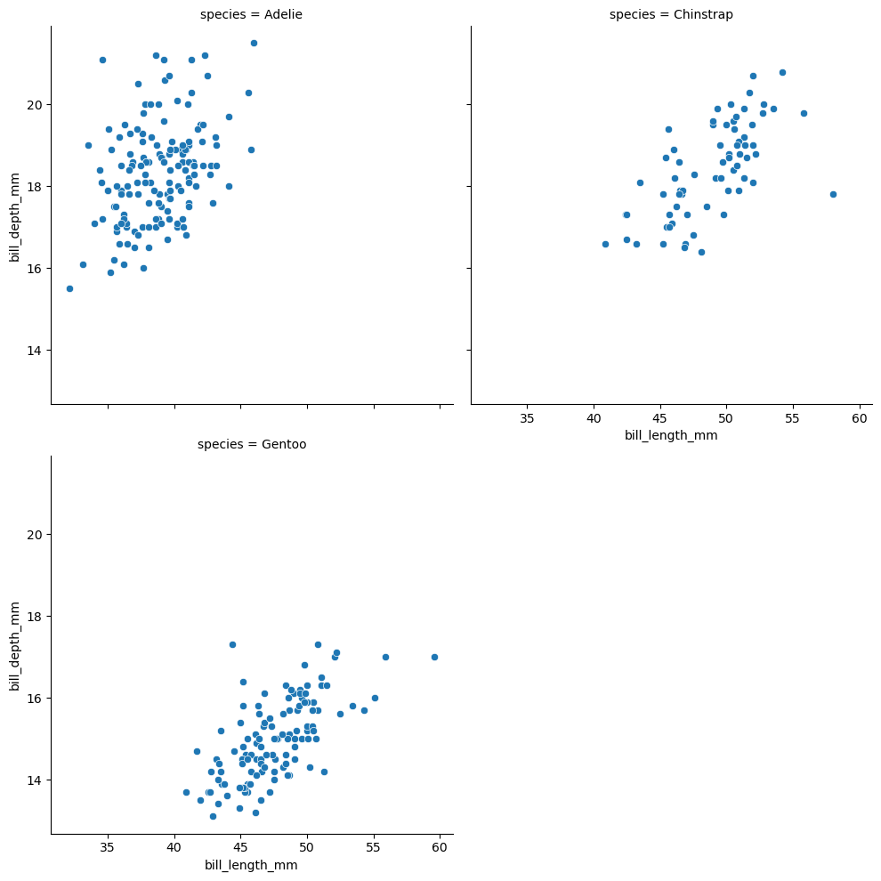

```python
sns.relplot(x='bill_length_mm', y='bill_depth_mm',
            col='species', col_wrap=2, kind='scatter', data=penguins)
```

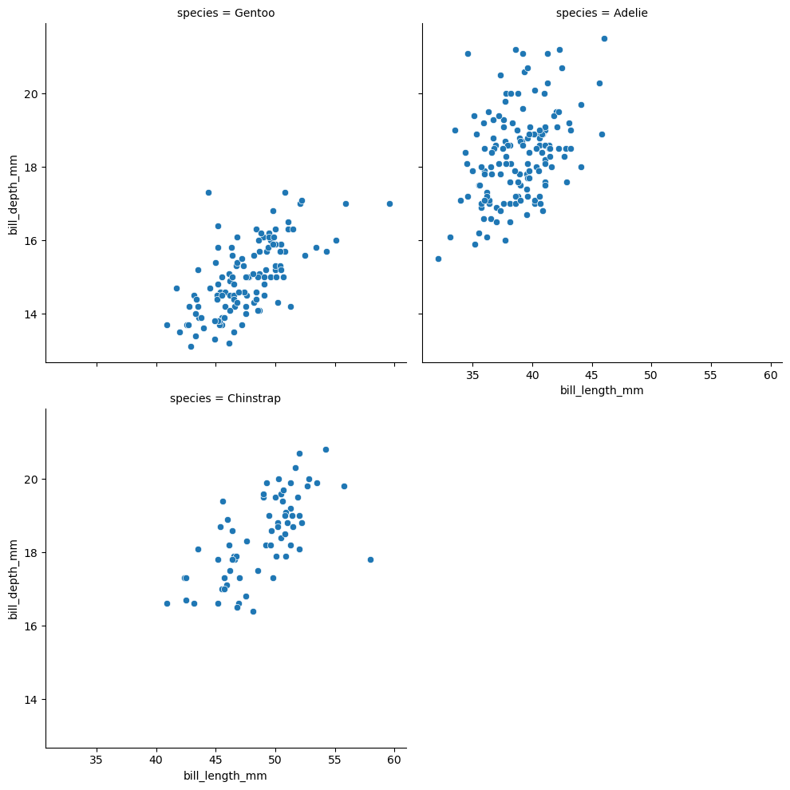

```python
sns.relplot(x='bill_length_mm', y='bill_depth_mm',
            col='species', col_wrap=2,
            col_order=['Gentoo','Adelie','Chinstrap'], kind='scatter', data=penguins)
```

### `catplot`

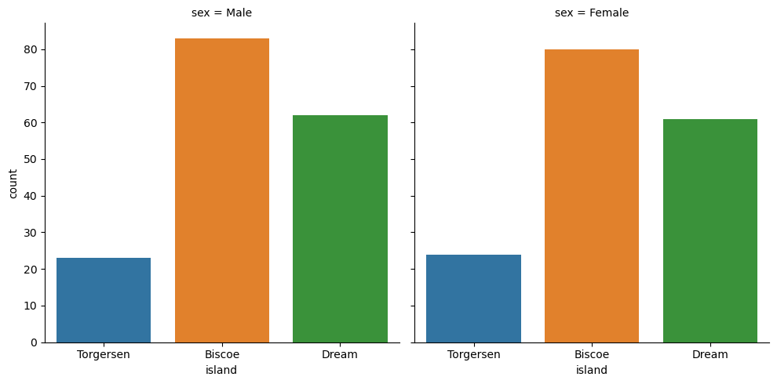

```python
sns.catplot(x='island', col='sex', kind='count', data=penguins)
```

## Bar plots

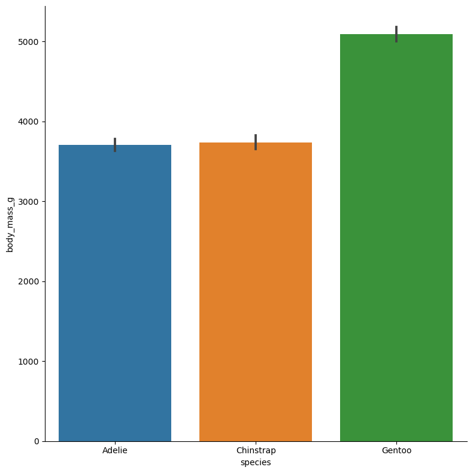

```python
sns.catplot(x='species', y='body_mass_g', kind='bar',
            height=8, aspect=8/8, data=penguins)
```

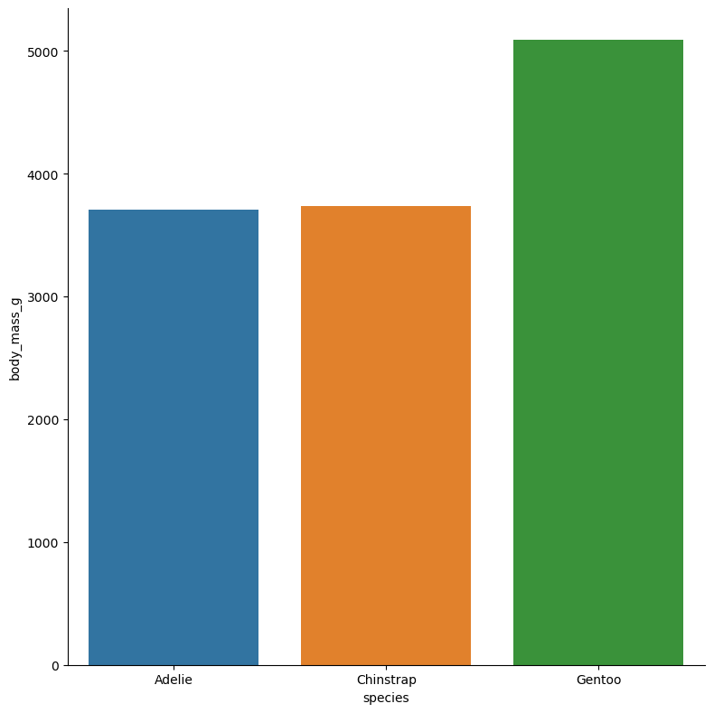

```python
sns.catplot(x='species', y='body_mass_g', ci=None,
            kind='bar',height=8, aspect=8/8, data=penguins)
```

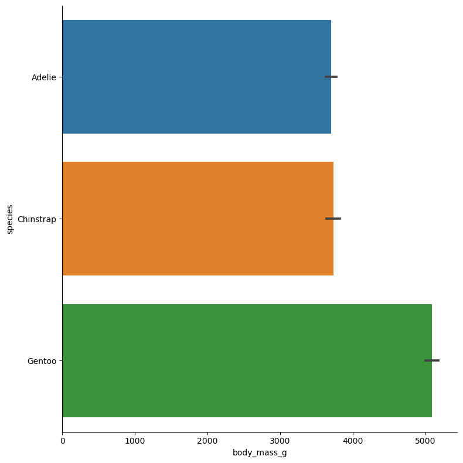

```python
sns.catplot(x='body_mass_g', y='species',
            kind='bar',height=8, aspect=8/8, data=penguins)
```

## Exercises

### Exercise 1

We will work with the `mpg` dataset. The dataset is available through the seaborn package. You will have to run the following: `mpg = sns.load_dataset('mpg')`.

- Create a kernel distribution plot for the horsepower column. Include ticks on the x axis for the actual data location.
- Create a histogram of the mpg column. Adjust the number of bins to 50.
- Create a scatter plot with the horsepower on the x axis and the mpg on the y axis. Use different colors to indicate the origin of each point.
- Same as above but this time use different colors to indicate the range of weight of each point.
- Create a jointplot depicting the regression line between horsepower and acceleration.
- Create separate scatter plots with the horsepower on the x axis and the mpg on the y axis for each value of the cylinders column. Arrange the plots in a single column format.
- Create separate scatter plots with the horsepower on the x axis and the acceleration on the y axis for each unique combination of origin and cylinders.
- Create a scatter plot depicting the residuals arising from regressing horsepower on mpg.
- Create a count plot based on the model_year column. Create separate plots for each `origin`.
- Create a bar plot for the acceleration of cars with different number of cylinders. Changer the orientation so that you have a horizontal bar plot.